# R Notebook

Descripción de los datos:

Response (y): Performance IQ scores (PIQ) from the revised Wechsler Adult Intelligence Scale. This variable served as the investigator’s measure of the individual’s intelligence. Potential predictor (x1): Brain size based on the count obtained from MRI scans (given as count/10,000). Potential predictor (x2): Height in inches. Potential predictor (x3): Weight in pounds.

Apartado A ¿ Depende el coeficiente intelectual de medidas físicas ? Carga “iqphys.csv” y haz una regresión lineal múltiple:

-¿ Cuál de los predictores explica algo la variabilidad del coeficiente intelctual? -¿ Cuál es el efecto del tamaño cerebral, después de tomar en cuenta el peso y la altura? -Da un intervalo de confianza para los coeficientes -¿ Cuál es el intervalo de confianza de IQ para los valores de los predictores: 95,70,180 ? -Siguen los residuos una distribución normal? Haz las representaciones del histograma y de de la gráfica cuantil-cuantil convenientes.

```r
rm(list=ls())
```

```r
CI <- read.csv(file="datos/CI.csv", header=TRUE, sep=",")
attach(CI)
```

Vamos a comprobar si hay valores nulos

```r
apply(is.na(CI),2,sum)
```

```
   PIQ  Brain Height Weight
     0      0      0      0
```

Vamos a pintar los datos para ver si hay algo anómalo

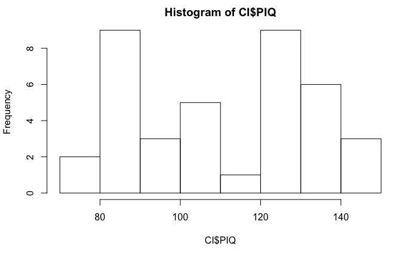

```r
hist(CI$PIQ)
```

```r
mean(CI$PIQ)
```

```
[1] 111.3421
```

```r
sd(CI$PIQ)
```

```
[1] 22.59787
```

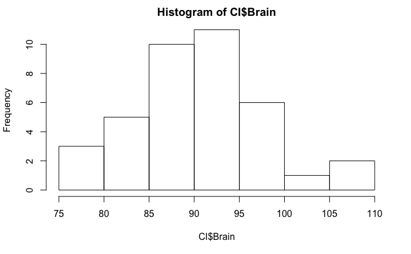

```r
hist(CI$Brain)
```

```r
mean(CI$Brain)
```

```
[1] 90.67579
```

```r
sd(CI$Brain)
```

```
[1] 7.256279
```

Vemos que no hay datos anómalos

```r
head(CI)
```

|  | PIQ | Brain | Height | Weight |
| --- | --- | --- | --- | --- |
| 1 | 124 | 81.69 | 64.5 | 118 |
| 2 | 150 | 103.84 | 73.3 | 143 |
| 3 | 128 | 96.54 | 68.8 | 172 |
| 4 | 134 | 95.15 | 65.0 | 147 |
| 5 | 110 | 92.88 | 69.0 | 146 |
| 6 | 131 | 99.13 | 64.5 | 138 |

Hacemos una regresión lineal múltiple para ver si podemos explicar el Coeficiente Intelectual

```r
modelo <- lm(PIQ~.,data=CI)
summary(modelo)
```

```
Call:
lm(formula = PIQ ~ ., data = CI)

Residuals:
   Min     1Q Median     3Q    Max
-32.74 -12.09  -3.84  14.17  51.69

Coefficients:
              Estimate Std. Error t value Pr(>|t|)
(Intercept)  1.114e+02  6.297e+01   1.768 0.085979 .
Brain        2.060e+00  5.634e-01   3.657 0.000856 ***
Height      -2.732e+00  1.229e+00  -2.222 0.033034 *
Weight       5.599e-04  1.971e-01   0.003 0.997750
---
Signif. codes:  0 ‘***’ 0.001 ‘**’ 0.01 ‘*’ 0.05 ‘.’ 0.1 ‘ ’ 1

Residual standard error: 19.79 on 34 degrees of freedom
Multiple R-squared:  0.2949,    Adjusted R-squared:  0.2327
F-statistic: 4.741 on 3 and 34 DF,  p-value: 0.007215
```

¿ Cuál de los predictores explica algo la variabilidad del coeficiente intelctual? Parece que el tamaño del cerebro y en menor medida la estatura. En todo caso viendo el R^2 vemos que el modelo es bastante pobre. De hecho el error standard en residuos es de 19.79 y la desviación típica de la variable PIQ es 22.59, lo que significa que hay una variación muy fuerte en los residuos respecto a la variable objetivo.

Sólo parece significativamente influyente el tamaño cerebral y un poco la altura sólo el 29% de la variabilidad del coeficiente intelectual queda explicada a través de las variables predictoras. -> Ver la R^2.

¿ Cuál es el efecto del tamaño cerebral, después de tomar en cuenta el peso y la altura? Vemos que el tamaño del cerebro puede tener una influencia positiva en el CI

```r
res <- cor(CI)
res
```

```
                PIQ     Brain      Height      Weight
PIQ     1.000000000 0.3778155 -0.09315559 0.002512154
Brain   0.377815463 1.0000000  0.58836684 0.513486971
Height -0.093155590 0.5883668  1.00000000 0.699614004
Weight  0.002512154 0.5134870  0.69961400 1.000000000
```

```r
library(ggplot2)
```

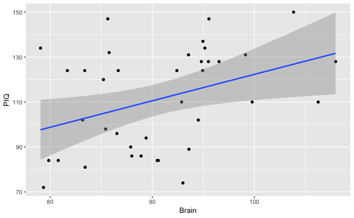

```r
b <- ggplot(CI, aes(x = Brain, y = PIQ))
# Scatter plot with regression line
b + geom_point()+
  geom_smooth(method = "lm")
```

Vamos a tratar de mejorar un poco el modelo.

```r
step <- stepAIC(lm(PIQ~1,data=CI),scope =
                  PIQ~Brain+Height+Weight, direction="forward")
```

```
Start:  AIC=237.94
PIQ ~ 1

         Df Sum of Sq   RSS    AIC
+ Brain   1   2697.09 16198 234.09
<none>                18895 237.94
+ Height  1    163.97 18731 239.61
+ Weight  1      0.12 18894 239.94

Step:  AIC=234.09
PIQ ~ Brain

         Df Sum of Sq   RSS    AIC
+ Height  1   2875.65 13322 228.66
+ Weight  1    940.94 15256 233.82
<none>                16198 234.09

Step:  AIC=228.66
PIQ ~ Brain + Height

         Df Sum of Sq   RSS    AIC
<none>                13322 228.66
+ Weight  1 0.0031633 13322 230.66
```

```r
step$anova # resultados
```

```
Stepwise Model Path
Analysis of Deviance Table

Initial Model:
PIQ ~ 1

Final Model:
PIQ ~ Brain + Height

      Step Df Deviance Resid. Df Resid. Dev      AIC
1                             37   18894.55 237.9436
2  + Brain  1 2697.094        36   16197.46 234.0909
3 + Height  1 2875.647        35   13321.81 228.6637
```

```r
modelo_2 <- lm(PIQ ~ Brain + Height,data= CI)
summary(modelo_2)
```

```
Call:
lm(formula = PIQ ~ Brain + Height, data = CI)

Residuals:
    Min      1Q  Median      3Q     Max
-32.750 -12.090  -3.841  14.174  51.690

Coefficients:
            Estimate Std. Error t value Pr(>|t|)
(Intercept) 111.2757    55.8673   1.992 0.054243 .
Brain         2.0606     0.5466   3.770 0.000604 ***
Height       -2.7299     0.9932  -2.749 0.009399 **
---
Signif. codes:  0 ‘***’ 0.001 ‘**’ 0.01 ‘*’ 0.05 ‘.’ 0.1 ‘ ’ 1

Residual standard error: 19.51 on 35 degrees of freedom
Multiple R-squared:  0.2949,    Adjusted R-squared:  0.2546
F-statistic: 7.321 on 2 and 35 DF,  p-value: 0.002208
```

Comparamos los dos modelos para ver con cual nos quedamos

```r
AIC(modelo)
```

```
[1] 340.503
```

```r
AIC(modelo_2)
```

```
[1] 338.5031
```

```r
anova(modelo,modelo_2)
```

```
Analysis of Variance Table

Model 1: PIQ ~ Brain + Height + Weight
Model 2: PIQ ~ Brain + Height
  Res.Df   RSS Df  Sum of Sq  F Pr(>F)
1     34 13322
2     35 13322 -1 -0.0031633  0 0.9977
```

Nos quedamos con el modelo que no incorpora el peso por tener un AIC menor. El p-valor es enorme, nos quedamos con el modelo simplificado

Da un intervalo de confianza para los coeficientes

```r
confint(modelo_2)
```

```
                 2.5 %      97.5 %
(Intercept) -2.1410228 224.6923622
Brain        0.9509088   3.1703892
Height      -4.7462046  -0.7136513
```

```r
Brain<-95
Height<-70
Weight<-180
datos_test<-data.frame(Brain,Height,Weight)
predict.lm(modelo_2,newdata=datos_test,interval="predict",level = 0.95)
```

```
       fit     lwr      upr
1 115.9424 75.6293 156.2554
```

```r
predict.lm(modelo_2,newdata=datos_test,interval="predict",level = 0.99)
```

```
       fit      lwr      upr
1 115.9424 61.85413 170.0306
```

Observamos que el tamaño del intervalo de confianza es muy amplio. Esto es porque hay pocas muestras y el predictor es malo.

Pintamos los residuos para confirmar que el predictor está bien diseñado:

Siguen los residuos una distribución normal? Haz las representaciones del histograma y de de la gráfica cuantil-cuantil convenientes.

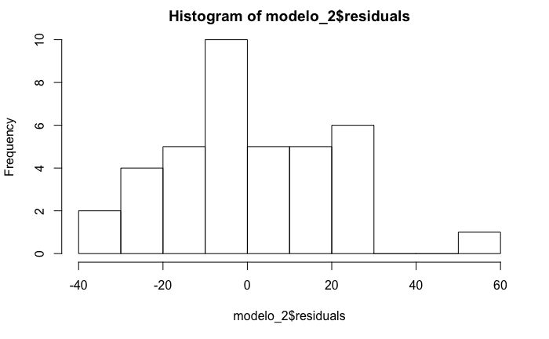

```r
hist(modelo_2$residuals)
```

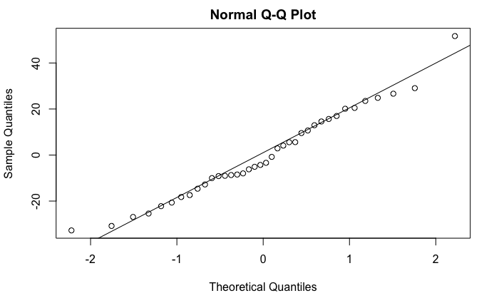

```r
qqnorm(modelo_2$residuals)
qqline(modelo_2$residuals)
```

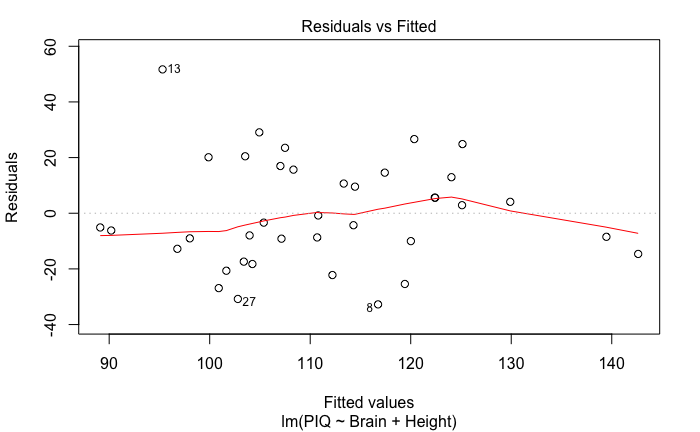

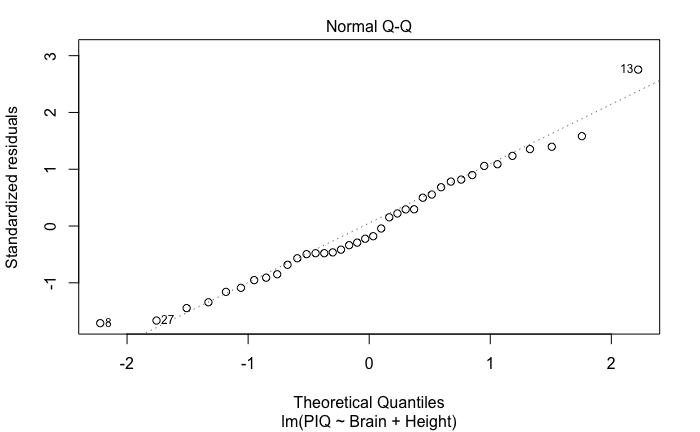

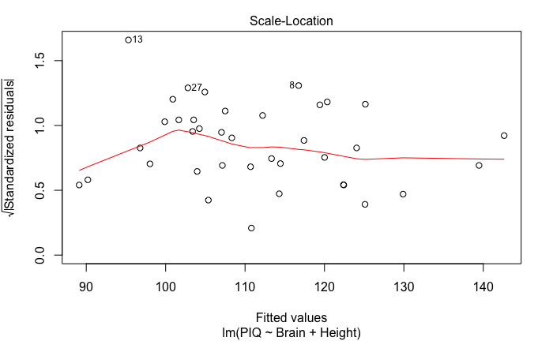

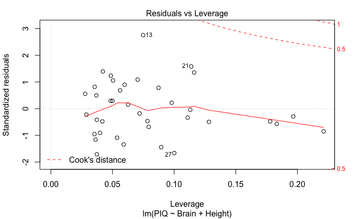

```r
plot(modelo_2)
```

```r
shapiro.test(modelo_2$residuals)
```

```
    Shapiro-Wilk normality test

data:  modelo_2$residuals
W = 0.976, p-value = 0.5764
```

Por los resultados del test de Shapiro, podemos considerar los residuos normales

APARTADO B

Carga el dataset prostate en el paquete ElemStatLearn Elimina la columna train ¿Cuál es el mejor modelo que explica la variable lpsa ? Da un intervalo de confianza para los coeficientes

```r
 install.packages("ElemStatLearn")
library(ElemStatLearn)
data("prostate")
help(prostate)
head(prostate)
```

|  | lcavol | lweight | age | lbph | svi | lcp | gleason | pgg45 | lpsa | train |
| --- | --- | --- | --- | --- | --- | --- | --- | --- | --- | --- |
| 1 | -0.5798185 | 2.769459 | 50 | -1.386294 | 0 | -1.386294 | 6 | 0 | -0.4307829 | TRUE |
| 2 | -0.9942523 | 3.319626 | 58 | -1.386294 | 0 | -1.386294 | 6 | 0 | -0.1625189 | TRUE |
| 3 | -0.5108256 | 2.691243 | 74 | -1.386294 | 0 | -1.386294 | 7 | 20 | -0.1625189 | TRUE |
| 4 | -1.2039728 | 3.282789 | 58 | -1.386294 | 0 | -1.386294 | 6 | 0 | -0.1625189 | TRUE |
| 5 | 0.7514161 | 3.432373 | 62 | -1.386294 | 0 | -1.386294 | 6 | 0 | 0.3715636 | TRUE |
| 6 | -1.0498221 | 3.228826 | 50 | -1.386294 | 0 | -1.386294 | 6 | 0 | 0.7654678 | TRUE |

```r
attach(prostate)
prostate$train <- NULL
```

```r
apply(is.na(CI),2,sum)
```

[output not shown]

```r
prostate
```

|  | lcavol | lweight | age | lbph | svi | lcp | gleason | pgg45 | lpsa |
| --- | --- | --- | --- | --- | --- | --- | --- | --- | --- |
| 1 | -0.579818495 | 2.769459 | 50 | -1.38629436 | 0 | -1.38629436 | 6 | 0 | -0.4307829 |
| 2 | -0.994252273 | 3.319626 | 58 | -1.38629436 | 0 | -1.38629436 | 6 | 0 | -0.1625189 |
| 3 | -0.510825624 | 2.691243 | 74 | -1.38629436 | 0 | -1.38629436 | 7 | 20 | -0.1625189 |
| 4 | -1.203972804 | 3.282789 | 58 | -1.38629436 | 0 | -1.38629436 | 6 | 0 | -0.1625189 |
| 5 | 0.751416089 | 3.432373 | 62 | -1.38629436 | 0 | -1.38629436 | 6 | 0 | 0.3715636 |
| 6 | -1.049822124 | 3.228826 | 50 | -1.38629436 | 0 | -1.38629436 | 6 | 0 | 0.7654678 |
| 7 | 0.737164066 | 3.473518 | 64 | 0.61518564 | 0 | -1.38629436 | 6 | 0 | 0.7654678 |
| 8 | 0.693147181 | 3.539509 | 58 | 1.53686722 | 0 | -1.38629436 | 6 | 0 | 0.8544153 |
| 9 | -0.776528789 | 3.539509 | 47 | -1.38629436 | 0 | -1.38629436 | 6 | 0 | 1.0473190 |
| 10 | 0.223143551 | 3.244544 | 63 | -1.38629436 | 0 | -1.38629436 | 6 | 0 | 1.0473190 |

[output cut: 87 more lines]

```r
prostate$gleason
```

```
 [1] 6 6 7 6 6 6 6 6 6 6 6 6 7 7 7 6 7 6 6 6 6 7 6 7 6 6 7 7 7 6 6 6 6 6 6 7 8 7 7 7 9 7 6 7 7 7 9 7 6 6 7 6 7 7 7 7 7 6 7 7 6
[62] 7 9 7 6 7 7 7 6 7 7 7 7 9 7 7 7 7 7 7 7 7 7 9 7 7 6 7 7 7 6 7 7 7 7 7 7
```

Cambiamos las variables que parecen factores

```r
fact.cols <- c("age","svi","gleason","pgg45")
prostate[fact.cols] <- lapply(prostate[fact.cols], factor)
str(prostate)
```

```
'data.frame':   97 obs. of  9 variables:
 $ lcavol : num  -0.58 -0.994 -0.511 -1.204 0.751 ...
 $ lweight: num  2.77 3.32 2.69 3.28 3.43 ...
 $ age    : Factor w/ 31 levels "41","43","44",..: 6 11 27 11 15 6 17 11 4 16 ...
 $ lbph   : num  -1.39 -1.39 -1.39 -1.39 -1.39 ...
 $ svi    : Factor w/ 2 levels "0","1": 1 1 1 1 1 1 1 1 1 1 ...
 $ lcp    : num  -1.39 -1.39 -1.39 -1.39 -1.39 ...
 $ gleason: Factor w/ 4 levels "6","7","8","9": 1 1 2 1 1 1 1 1 1 1 ...
 $ pgg45  : Factor w/ 19 levels "0","4","5","6",..: 1 1 7 1 1 1 1 1 1 1 ...
 $ lpsa   : num  -0.431 -0.163 -0.163 -0.163 0.372 ...
```

```r
step <- stepAIC(lm(lpsa~1,data=prostate),scope =
                  lpsa~lcavol+lweight+age+lbph+svi+lcp+gleason+pgg45, direction="forward")
```

```
Start:  AIC=28.84
lpsa ~ 1

          Df Sum of Sq     RSS     AIC
+ lcavol   1    69.003  58.915 -44.366
+ svi      1    41.011  86.907  -6.658
+ lcp      1    38.528  89.389  -3.926
+ gleason  3    30.548  97.370   8.369
+ lweight  1    24.019 103.899  10.665
+ age     30    62.172  65.745  24.275
+ lbph     1     4.136 123.782  27.650
+ pgg45   18    40.359  87.559  28.067
<none>                 127.918  28.838

Step:  AIC=-44.37
lpsa ~ lcavol

          Df Sum of Sq    RSS     AIC
+ lweight  1    7.1726 51.742 -54.958
+ svi      1    5.2375 53.677 -51.397
+ lbph     1    3.2658 55.649 -47.898
<none>                 58.915 -44.366
+ lcp      1    0.6562 58.259 -43.452
+ gleason  3    2.8395 56.075 -43.158
+ pgg45   18   10.9031 48.012 -28.217
+ age     30   17.2954 41.619 -18.076

Step:  AIC=-54.96
lpsa ~ lcavol + lweight

          Df Sum of Sq    RSS     AIC
+ svi      1    5.1737 46.568 -63.177
<none>                 51.742 -54.958
+ lcp      1    0.8187 50.923 -54.506
+ gleason  3    2.7992 48.943 -54.353
+ lbph     1    0.4440 51.298 -53.794
+ pgg45   18   14.1343 37.608 -49.907
+ age     30   14.5183 37.224 -26.903

Step:  AIC=-63.18
lpsa ~ lcavol + lweight + svi

          Df Sum of Sq    RSS     AIC
+ lbph     1    0.9730 45.595 -63.226
<none>                 46.568 -63.177
+ lcp      1    0.0694 46.499 -61.322
+ gleason  3    1.6414 44.927 -60.658
+ pgg45   18   13.5268 33.042 -60.464
+ age     30   12.1530 34.415 -32.512

Step:  AIC=-63.23
lpsa ~ lcavol + lweight + svi + lbph

          Df Sum of Sq    RSS     AIC
<none>                 45.595 -63.226
+ lcp      1    0.1012 45.494 -61.441
+ pgg45   18   13.1200 32.475 -60.140
+ gleason  3    1.2635 44.332 -59.951
+ age     30   12.3168 33.279 -33.770
```

```r
step$anova
```

```
Stepwise Model Path
Analysis of Deviance Table

Initial Model:
lpsa ~ 1

Final Model:
lpsa ~ lcavol + lweight + svi + lbph

       Step Df   Deviance Resid. Df Resid. Dev       AIC
1                                96  127.91766  28.83755
2  + lcavol  1 69.0028748        95   58.91478 -44.36603
3 + lweight  1  7.1726080        94   51.74218 -54.95846
4     + svi  1  5.1737396        93   46.56844 -63.17744
5    + lbph  1  0.9729643        92   45.59547 -63.22555
```

```r
summary(step)
```

```
Call:
lm(formula = lpsa ~ lcavol + lweight + svi + lbph, data = prostate)

Residuals:
     Min       1Q   Median       3Q      Max
-1.85483 -0.35990 -0.01492  0.44467  1.53051

Coefficients:
            Estimate Std. Error t value Pr(>|t|)
(Intercept)  -0.3409     0.6936  -0.492  0.62420
lcavol        0.5285     0.0745   7.094 2.63e-10 ***
lweight       0.5360     0.1964   2.729  0.00761 **
svi1          0.7055     0.2080   3.392  0.00102 **
lbph          0.0786     0.0561   1.401  0.16454
---
Signif. codes:  0 ‘***’ 0.001 ‘**’ 0.01 ‘*’ 0.05 ‘.’ 0.1 ‘ ’ 1

Residual standard error: 0.704 on 92 degrees of freedom
Multiple R-squared:  0.6436,    Adjusted R-squared:  0.6281
F-statistic: 41.53 on 4 and 92 DF,  p-value: < 2.2e-16
```

```r
modelo<-lm(lpsa~lcavol+lweight+svi+lbph,data=prostate)
summary(modelo)
```

```
Call:
lm(formula = lpsa ~ lcavol + lweight + svi + lbph, data = prostate)

Residuals:
     Min       1Q   Median       3Q      Max
-1.85483 -0.35990 -0.01492  0.44467  1.53051

Coefficients:
            Estimate Std. Error t value Pr(>|t|)
(Intercept)  -0.3409     0.6936  -0.492  0.62420
lcavol        0.5285     0.0745   7.094 2.63e-10 ***
lweight       0.5360     0.1964   2.729  0.00761 **
svi1          0.7055     0.2080   3.392  0.00102 **
lbph          0.0786     0.0561   1.401  0.16454
---
Signif. codes:  0 ‘***’ 0.001 ‘**’ 0.01 ‘*’ 0.05 ‘.’ 0.1 ‘ ’ 1

Residual standard error: 0.704 on 92 degrees of freedom
Multiple R-squared:  0.6436,    Adjusted R-squared:  0.6281
F-statistic: 41.53 on 4 and 92 DF,  p-value: < 2.2e-16
```

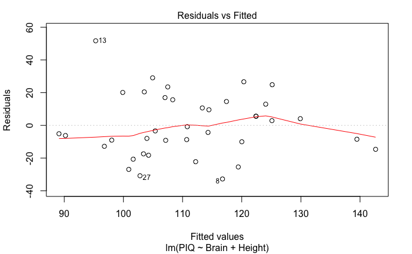

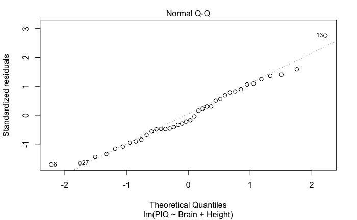

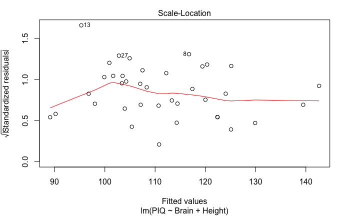

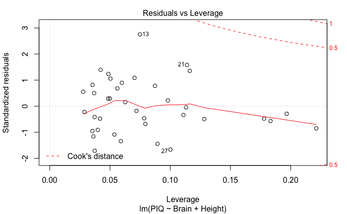

```r
plot(modelo_2)
```

```r
confint(modelo)
```

```
                  2.5 %    97.5 %
(Intercept) -1.71848404 1.0365946
lcavol       0.38052247 0.6764587
lweight      0.14591157 0.9261602
svi1         0.29242262 1.1185395
lbph        -0.03281341 0.1900113
```

```r
step2 <- stepAIC(lm(lpsa~1,data=prostate),scope =
                  lpsa~lcavol+lweight+age+lbph+svi+lcp+gleason+pgg45, direction="both")
```

```
Start:  AIC=28.84
lpsa ~ 1

          Df Sum of Sq     RSS     AIC
+ lcavol   1    69.003  58.915 -44.366
+ svi      1    41.011  86.907  -6.658
+ lcp      1    38.528  89.389  -3.926
+ gleason  3    30.548  97.370   8.369
+ lweight  1    24.019 103.899  10.665
+ age     30    62.172  65.745  24.275
+ lbph     1     4.136 123.782  27.650
+ pgg45   18    40.359  87.559  28.067
<none>                 127.918  28.838

Step:  AIC=-44.37
lpsa ~ lcavol

          Df Sum of Sq     RSS     AIC
+ lweight  1     7.173  51.742 -54.958
+ svi      1     5.237  53.677 -51.397
+ lbph     1     3.266  55.649 -47.898
<none>                  58.915 -44.366
+ lcp      1     0.656  58.259 -43.452
+ gleason  3     2.840  56.075 -43.158
+ pgg45   18    10.903  48.012 -28.217
+ age     30    17.295  41.619 -18.076
- lcavol   1    69.003 127.918  28.838

Step:  AIC=-54.96
lpsa ~ lcavol + lweight

          Df Sum of Sq     RSS     AIC
+ svi      1     5.174  46.568 -63.177
<none>                  51.742 -54.958
+ lcp      1     0.819  50.923 -54.506
+ gleason  3     2.799  48.943 -54.353
+ lbph     1     0.444  51.298 -53.794
+ pgg45   18    14.134  37.608 -49.907
- lweight  1     7.173  58.915 -44.366
+ age     30    14.518  37.224 -26.903
```

[output cut: 14 more lines]

```
- lcavol   1   24.7058 71.274 -23.893

Step:  AIC=-63.23
lpsa ~ lcavol + lweight + svi + lbph

          Df Sum of Sq    RSS     AIC
<none>                 45.595 -63.226
- lbph     1    0.9730 46.568 -63.177
+ lcp      1    0.1012 45.494 -61.441
+ pgg45   18   13.1200 32.475 -60.140
+ gleason  3    1.2635 44.332 -59.951
- lweight  1    3.6907 49.286 -57.675
- svi      1    5.7027 51.298 -53.794
+ age     30   12.3168 33.279 -33.770
- lcavol   1   24.9384 70.534 -22.906
```

```r
step2$anova
```

```
Stepwise Model Path
Analysis of Deviance Table

Initial Model:
lpsa ~ 1

Final Model:
lpsa ~ lcavol + lweight + svi + lbph

       Step Df   Deviance Resid. Df Resid. Dev       AIC
1                                96  127.91766  28.83755
2  + lcavol  1 69.0028748        95   58.91478 -44.36603
3 + lweight  1  7.1726080        94   51.74218 -54.95846
4     + svi  1  5.1737396        93   46.56844 -63.17744
5    + lbph  1  0.9729643        92   45.59547 -63.22555
```

```r
anova(lm(formula = lpsa ~ lcavol + lweight + svi + lbph, data = prostate),
      lm(formula = lpsa ~ lcavol + lweight + svi + lbph + age, data = prostate))
```

```
Analysis of Variance Table

Model 1: lpsa ~ lcavol + lweight + svi + lbph
Model 2: lpsa ~ lcavol + lweight + svi + lbph + age
  Res.Df    RSS Df Sum of Sq      F Pr(>F)
1     92 45.595
2     62 33.279 30    12.317 0.7649 0.7872
```